# Project_2_b

Justin Herman

March 11, 2018

```r
library(tidyverse)
library(kableExtra)
library(knitr)
library(stringr)
library(readr)
library(plyr)
library(dplyr)
library(data.table)
library(readxl)
require(xlsx)
library(rJava)
library(xlsx)
```

## World Bank info for Infant Mortality and Tuberculosis

- Binish recommended this dataset website
- [link to source](http://apps.who.int/gho/data/node.country.country)
- Randomly chose 4 countires with the letter `U`
- Read in files individually/with functional

```r
#Manually Load in CSV
Uganda<- read.csv("uganda.csv",na.strings=c("","NA"))
Ukraine <- read.csv("Ukraine.csv",na.strings=c("","NA"))
United_kingdom <- read.csv("United_Kingdom.csv",na.strings=c("","NA"))
United_states <- read.csv("United_states.csv",na.strings=c("","NA"))


# Functional to load csv
files <- c("Uganda.csv", "Ukraine.csv", "United_Kingdom.csv", "United_states.csv")
temp = files
myfiles <-lapply(temp,read.csv)
```

## Join on shared row index values(survey questions)

- This will decrease our sample to only those questions that are answered in every dataset

```r
merged_df<- inner_join(United_states,United_kingdom) %>%
    inner_join(.,Ukraine) %>%
    inner_join(.,Uganda)

# With Functional data
merged_df_2<- inner_join(myfiles[[1]],myfiles[[2]]) %>%
    inner_join(myfiles[[3]]) %>%
    inner_join(myfiles[[4]])
```

```r
kable(merged_df_2[1:15,])
```

| X | Uganda | Uganda.1 | Uganda.2 | Uganda.3 | Uganda.4 | Uganda.5 | Uganda.6 | Uganda.7 | Uganda.8 | Uganda.9 | Uganda.10 | Uganda.11 | Uganda.12 | Uganda.13 | Ukraine | Ukraine.1 | Ukraine.2 | Ukraine.3 | Ukraine.4 | Ukraine.5 | Ukraine.6 | Ukraine.7 | Ukraine.8 | Ukraine.9 | Ukraine.10 | Ukraine.11 | Ukraine.12 | Ukraine.13 | United.Kingdom.of.Great.Britain.and.Northern.Ireland | … |
| --- | --- | --- | --- | --- | --- | --- | --- | --- | --- | --- | --- | --- | --- | --- | --- | --- | --- | --- | --- | --- | --- | --- | --- | --- | --- | --- | --- | --- | --- | --- |
| Indicator | 2015 | 2014 | 2013 | 2012 | 2011 | 2010 | 2009 | 2008 | 2007 | 2006 | 2005 | 2004 | 2003 | 2002 | 2015 | 2014 | 2013 | 2012 | 2011 | 2010 | 2009 | 2008 | 2007 | 2006 | 2005 | 2004 | 2003 | 2002 | 2015 | … |
| Antiretroviral therapy coverage among people with HIV infection eligible for ART according to 2010 guidelines (%) |  |  |  | 64 [57-71] |  |  |  |  |  |  |  |  |  |  |  |  |  | 41 [36-47] |  |  |  |  |  |  |  |  |  |  |  | … |
| Cellular subscribers (per 100 population) |  |  |  | 45 | 48 | 38 |  |  |  |  |  |  |  |  |  |  |  | 130 | 123 | 119 |  |  |  |  |  |  |  |  |  | … |
| Civil registration coverage of births (%) |  |  |  |  | 29.9 |  |  |  |  |  |  |  |  |  |  |  |  | 99.8 |  |  |  |  |  |  | 99.8 |  |  |  | 100 | … |
| Gross national income per capita (PPP int. $) |  |  |  | 1320 | 1310 | 1240 | 1200 | 1150 | 1070 | 990 | 890 | 840 | 800 | 760 |  |  |  | 8670 | 8170 | 7590 | 7130 | 8370 | 7930 | 7110 | 6410 | 6000 | 5170 | 4590 |  | … |
| Prevalence of HIV among adults aged 15 to 49 (%) |  |  |  |  |  | 7.4 [6.9-7.8] |  |  |  |  | 7.9 [7.3-8.4] |  |  |  |  |  |  |  |  | 0.8 [0.8-0.8] |  |  |  |  | 0.8 [0.7-0.8] |  |  |  |  | … |
| Total fertility rate (per woman) |  |  | 5.9 | 5.96 | 6.06 |  |  |  |  |  |  |  |  |  |  |  | 1.5 | 1.46 | 1.45 |  |  |  |  |  |  |  |  |  |  | … |
| Tuberculosis treatment coverage | 52 [34-87] | 56 [39-89] | 60 [42-91] | 60 [43-91] | 64 [47-92] | 60 [43-91] | 60 [42-91] | 61 [44-92] | 60 [43-92] | 61 [43-92] | 62 [44-92] | 66 [49-94] | 65 [48-94] | 62 [44-92] | 74 [52-110] | 75 [52-120] | 84 [59-130] | 90 [63-140] | 71 [50-110] | 67 [47-100] | 68 [48-110] | 69 [48-110] | 66 [46-100] | 71 [49-110] | 67 [47-100] | No data | 130 [91-200] | 68 [48-110] | 89 [81-98] | … |
| Number of under-five deaths (thousands) | 93 | 97 | 103 | 109 | 114 | 119 | 124 | 130 | 137 | 145 | 155 | 164 | 173 | 181 | 5 | 5 | 5 | 5 | 5 | 6 | 6 | 6 | 6 | 6 | 6 | 6 | 6 | 7 | 4 | … |
| Infant mortality rate (probability of dying between birth and age 1 per 1000 live births) | 39.2 [35.4-43.3] | 41.0 [37.8-44.5] | 43.9 [40.8-47.2] | 46.5 [43.2-50.0] | 49.5 [46.1-53.3] | 52.7 [49.2-56.4] | 55.7 [52.2-59.3] | 58.9 [55.4-62.5] | 63.3 [59.6-67.3] | 68.6 [64.7-72.7] | 74.4 [70.3-78.7] | 80.5 [76.3-85.0] | 86.7 [82.0-91.4] | 92.5 [87.5-97.5] | 8.1 [7.8-8.4] | 8.4 [8.1-8.7] | 8.8 [8.5-9.0] | 9.2 [8.9-9.4] | 9.6 [9.3-9.9] | 10.1 [9.8-10.4] | 10.6 [10.3-10.9] | 11.1 [10.8-11.4] | 11.6 [11.3-11.9] | 12.0 [11.7-12.3] | 12.5 [12.0-12.9] | 13.0 [12.3-13.6] | 13.7 [12.8-14.5] | 14.3 [13.2-15.4] | 3.7 [3.6-3.9] | … |
| Number of infant deaths (thousands) | 66 | 68 | 71 | 73 | 76 | 79 | 82 | 84 | 88 | 93 | 99 | 104 | 109 | 112 | 4 | 4 | 4 | 5 | 5 | 5 | 5 | 5 | 5 | 5 | 5 | 5 | 6 | 6 | 3 | … |
| Number of neonatal deaths (thousands) | 38 | 38 | 38 | 38 | 38 | 38 | 38 | 38 | 38 | 38 | 38 | 39 | 39 | 40 | 3 | 3 | 3 | 3 | 3 | 3 | 4 | 4 | 4 | 4 | 4 | 4 | 4 | 4 | 2 | … |
| Neonatal mortality rate (per 1000 live births) | 22.0 [18.4-26.2] | 22.6 [19.4-26.4] | 23.3 [20.1-26.8] | 23.9 [20.7-27.4] | 24.4 [21.3-27.9] | 24.9 [21.8-28.3] | 25.4 [22.4-28.6] | 26.0 [23.0-29.2] | 26.6 [23.6-30.0] | 27.4 [24.2-30.8] | 28.3 [24.8-31.9] | 29.4 [25.8-33.0] | 30.5 [26.9-34.4] | 31.9 [28.1-35.9] | 5.6 [3.7-7.2] | 5.9 [3.9-7.5] | 6.1 [4.2-7.7] | 6.4 [4.4-8.0] | 6.7 [4.8-8.3] | 7.0 [5.1-8.6] | 7.4 [5.5-8.9] | 7.7 [5.8-9.3] | 8.0 [6.2-9.5] | 8.4 [6.6-9.8] | 8.7 [7.0-10.0] | 9.1 [7.5-10.4] | 9.5 [7.9-11.0] | 10.0 [8.4-11.6] | 2.7 [2.2-3.1] | … |
| Under-five mortality rate (probability of dying by age 5 per 1000 live births) | 55.9 [49.3-63.3] | 60.1 [54.4-66.4] | 65.0 [59.4-71.1] | 70.2 [64.1-76.8] | 75.5 [69.1-82.3] | 81.0 [74.6-87.7] | 86.4 [80.1-93.0] | 92.6 [86.2-99.4] | 100.5 [93.6-107.7] | 109.8 [102.7-117.3] | 120.3 [112.8-128.3] | 131.3 [123.5-139.6] | 142.5 [133.9-151.3] | 153.1 [143.8-162.6] | 9.4 [9.1-9.8] | 9.8 [9.5-10.1] | 10.2 [9.9-10.5] | 10.7 [10.3-11.0] | 11.2 [10.8-11.5] | 11.7 [11.4-12.1] | 12.3 [12.0-12.7] | 12.9 [12.5-13.2] | 13.4 [13.1-13.8] | 14.0 [13.6-14.3] | 14.5 [13.9-15.0] | 15.1 [14.3-15.8] | 15.9 [14.8-16.8] | 16.7 [15.4-18.0] | 4.4 [4.3-4.6] | … |
| Contraceptive prevalence (%) |  |  |  |  | 30 |  |  |  |  |  |  |  |  |  |  |  |  | 65.4 |  |  |  |  | 66.7 |  |  |  |  |  |  | … |

## Tidy Dataset

```r
getting_tidy <- merged_df[-(1),] %>%
    gather(United_states,Values,2:57) %>%
    mutate(Year=rep(unlist(lapply(2015:2002,function(x) rep(x,23))),4)) %>%
    spread(X, Values)
# I commented this section out because I could separate on my special characters, and contine my pipe, but I would still have to edit some speical characters out
    #separate(.,`Infant mortality rate (probability of dying between birth and age 1 per 1000 live births)`,into=c('Mean_Infant mortality_Rate/1000','Min_Infant_Mortality rate',"Max_Infant_Mortality_Rate"),sep= "\\[|-")
```

## Get rid of special characters `]` `[` `-` and add spacing for next pipe of tidying

- Use pipe to Tidy `Mean[min-max]` columns into mean,min,max columns

```r
getting_tidy <-  as_data_frame(lapply(getting_tidy,function(x){ str_replace_all(x,"\\]|\\["," ")}))
getting_tidy <-  as_data_frame(lapply(getting_tidy,function(x){ str_replace_all(x,"-","  ")}))



final_df <- getting_tidy %>%
    separate(.,`Incidence of tuberculosis (per 100 000 population per year)`,into=c('Mean_Incidence_Tuberculosis_100,000','Min_Tuberculosis',"Max_Tuberculosis")) %>%
    separate(.,`Antiretroviral therapy coverage among people with HIV infection eligible for ART according to 2010 guidelines (%)`,into=c('Mean_Antiretroviral_coverage','Min_Antiretroviral_coverage','Max_Antiretroviral_coverage')) %>%
    separate(.,`Infant mortality rate (probability of dying between birth and age 1 per 1000 live births)`,into=c('Mean_Infant mortality_Rate/1000','Min_Infant_Mortality rate',"Max_Infant_Mortality_Rate"),sep= "  ") %>%
    separate(.,`Under-five mortality rate (probability of dying by age 5 per 1000 live births)`,into=c('Mean_Under-five_Mortality_Rate/1000','Min_Under-five_Mortality_Rate',"Max_Under-five_Mortality_Rate"), sep="  ") %>%
    separate(.,`Tuberculosis treatment coverage`,into=c('Mean_Tuberculosis_Coverage','Min_Tuberculosis_Coverage',"Max_Tuberculosis_Coverage"))
```

## More piping

- First column needs to be renamed to country column
- Eliminate the .integers after the values in country column
- Trim df
- Convert columns to numeric for analysis

```r
final_df %<>%
    plyr::rename(.,c('United_states'= 'Country')) %>%
    mutate(Country=rep(c("Uganda","Ukraine","United_Kingdom","United_States"),each=14)) %>%
    select(colnames(.)[c(1,2,10,11,12,13,14,15,16,17,21,22,23,30,31,32,33,34,35)]) %>%
    arrange(.,`Country`)

final_df[] <- lapply(final_df,function(x){ str_trim(x)})
final_df[3:19] <- lapply(final_df[3:19],function(x) as.numeric(as.character(x)))
final_df <- as_data_frame(final_df)
kable(final_df)
```

| Country | Year | Gross national income per capita (PPP int. $) | Hospital beds (per 10 000 population) | Mean_Incidence_Tuberculosis_100,000 | Min_Tuberculosis | Max_Tuberculosis | Mean_Infant mortality_Rate/1000 | Min_Infant_Mortality rate | Max_Infant_Mortality_Rate | Number of neonatal deaths (thousands) | Number of under-five deaths (thousands) | Poliomyelitis - number of reported cases | Mean_Tuberculosis_Coverage | Min_Tuberculosis_Coverage | Max_Tuberculosis_Coverage | Mean_Under-five_Mortality_Rate/1000 | Min_Under-five_Mortality_Rate | Max_Under-five_Mortality_Rate |
| --- | --- | --- | --- | --- | --- | --- | --- | --- | --- | --- | --- | --- | --- | --- | --- | --- | --- | --- |
| Uganda | 2015 | NA | NA | 202 | 120 | 304 | 39.2 | 35.4 | 43.3 | 38 | 93 | NA | 52 | 34 | 87 | 55.9 | 49.3 | 63.3 |
| Uganda | 2014 | NA | NA | 202 | 127 | 294 | 41.0 | 37.8 | 44.5 | 38 | 97 | 0 | 56 | 39 | 89 | 60.1 | 54.4 | 66.4 |
| Uganda | 2005 | 890 | NA | 233 | 156 | 325 | 74.4 | 70.3 | 78.7 | 38 | 155 | NA | 62 | 44 | 92 | 120.3 | 112.8 | 128.3 |
| Uganda | 2004 | 840 | NA | 240 | 169 | 323 | 80.5 | 76.3 | 85.0 | 39 | 164 | NA | 66 | 49 | 94 | 131.3 | 123.5 | 139.6 |
| Uganda | 2003 | 800 | NA | 248 | 172 | 336 | 86.7 | 82.0 | 91.4 | 39 | 173 | NA | 65 | 48 | 94 | 142.5 | 133.9 | 151.3 |
| Uganda | 2002 | 760 | NA | 256 | 171 | 358 | 92.5 | 87.5 | 97.5 | 40 | 181 | NA | 62 | 44 | 92 | 153.1 | 143.8 | 162.6 |
| Uganda | 2013 | NA | NA | 203 | 134 | 288 | 43.9 | 40.8 | 47.2 | 38 | 103 | 0 | 60 | 42 | 91 | 65.0 | 59.4 | 71.1 |
| Uganda | 2012 | 1320 | NA | 205 | 135 | 289 | 46.5 | 43.2 | 50.0 | 38 | 109 | NA | 60 | 43 | 91 | 70.2 | 64.1 | 76.8 |
| Uganda | 2011 | 1310 | NA | 207 | 143 | 283 | 49.5 | 46.1 | 53.3 | 38 | 114 | NA | 64 | 47 | 92 | 75.5 | 69.1 | 82.3 |
| Uganda | 2010 | 1240 | 5 | 210 | 139 | 296 | 52.7 | 49.2 | 56.4 | 38 | 119 | NA | 60 | 43 | 91 | 81.0 | 74.6 | 87.7 |
| Uganda | 2009 | 1200 | 4 | 213 | 140 | 302 | 55.7 | 52.2 | 59.3 | 38 | 124 | NA | 60 | 42 | 91 | 86.4 | 80.1 | 93.0 |
| Uganda | 2008 | 1150 | NA | 217 | 145 | 304 | 58.9 | 55.4 | 62.5 | 38 | 130 | NA | 61 | 44 | 92 | 92.6 | 86.2 | 99.4 |
| Uganda | 2007 | 1070 | NA | 222 | 146 | 313 | 63.3 | 59.6 | 67.3 | 38 | 137 | NA | 60 | 43 | 92 | 100.5 | 93.6 | 107.7 |
| Uganda | 2006 | 990 | NA | 227 | 150 | 319 | 68.6 | 64.7 | 72.7 | 38 | 145 | NA | 61 | 43 | 92 | 109.8 | 102.7 | 117.3 |
| Ukraine | 2015 | NA | NA | 91 | 59 | 130 | 8.1 | 7.8 | 8.4 | 3 | 5 | NA | 74 | 52 | 110 | 9.4 | 9.1 | 9.8 |
| Ukraine | 2014 | NA | NA | 94 | 61 | 135 | 8.4 | 8.1 | 8.7 | 3 | 5 | 0 | 75 | 52 | 120 | 9.8 | 9.5 | 10.1 |
| Ukraine | 2005 | 6410 | 87 | 127 | 82 | 181 | 12.5 | 12.0 | 12.9 | 4 | 6 | NA | 67 | 47 | 100 | 14.5 | 13.9 | 15.0 |
| Ukraine | 2004 | 6000 | 87 | 127 | 82 | 182 | 13.0 | 12.3 | 13.6 | 4 | 6 | NA | NA | NA | NA | 15.1 | 14.3 | 15.8 |
| Ukraine | 2003 | 5170 | 88 | 126 | 81 | 180 | 13.7 | 12.8 | 14.5 | 4 | 6 | NA | 130 | 91 | 200 | 15.9 | 14.8 | 16.8 |
| Ukraine | 2002 | 4590 | 89 | 123 | 80 | 176 | 14.3 | 13.2 | 15.4 | 4 | 7 | NA | 68 | 48 | 110 | 16.7 | 15.4 | 18.0 |
| Ukraine | 2013 | NA | 88 | 96 | 62 | 138 | 8.8 | 8.5 | 9.0 | 3 | 5 | 0 | 84 | 59 | 130 | 10.2 | 9.9 | 10.5 |
| Ukraine | 2012 | 8670 | 89 | 101 | 65 | 144 | 9.2 | 8.9 | 9.4 | 3 | 5 | NA | 90 | 63 | 140 | 10.7 | 10.3 | 11.0 |
| Ukraine | 2011 | 8170 | 90 | 105 | 68 | 150 | 9.6 | 9.3 | 9.9 | 3 | 5 | NA | 71 | 50 | 110 | 11.2 | 10.8 | 11.5 |
| Ukraine | 2010 | 7590 | 94 | 110 | 71 | 157 | 10.1 | 9.8 | 10.4 | 3 | 6 | NA | 67 | 47 | 100 | 11.7 | 11.4 | 12.1 |
| Ukraine | 2009 | 7130 | 94 | 115 | 74 | 164 | 10.6 | 10.3 | 10.9 | 4 | 6 | NA | 68 | 48 | 110 | 12.3 | 12.0 | 12.7 |
| Ukraine | 2008 | 8370 | 87 | 119 | 77 | 170 | 11.1 | 10.8 | 11.4 | 4 | 6 | NA | 69 | 48 | 110 | 12.9 | 12.5 | 13.2 |
| Ukraine | 2007 | 7930 | 87 | 123 | 79 | 175 | 11.6 | 11.3 | 11.9 | 4 | 6 | NA | 66 | 46 | 100 | 13.4 | 13.1 | 13.8 |
| Ukraine | 2006 | 7110 | 87 | 125 | 81 | 179 | 12.0 | 11.7 | 12.3 | 4 | 6 | NA | 71 | 49 | 110 | 14.0 | 13.6 | 14.3 |
| United_Kingdom | 2015 | NA | NA | 10 | 9 | 1 | 3.7 | 3.6 | 3.9 | 2 | 4 | NA | 89 | 81 | 98 | 4.4 | 4.3 | 4.6 |
| United_Kingdom | 2014 | NA | NA | 11 | 10 | 13 | 3.8 | 3.7 | 3.9 | 2 | 4 | 0 | 89 | 81 | 98 | 4.5 | 4.4 | 4.6 |
| United_Kingdom | 2005 | 33820 | 37 | 15 | 14 | 17 | 5.1 | 5.0 | 5.2 | 3 | 4 | NA | 89 | 81 | 98 | 6.0 | 5.9 | 6.2 |
| United_Kingdom | 2004 | 32430 | 39 | 13 | 12 | 15 | 5.3 | 5.2 | 5.4 | 2 | 4 | NA | 89 | 81 | 98 | 6.2 | 6.0 | 6.3 |
| United_Kingdom | 2003 | 30450 | 40 | 13 | 12 | 15 | 5.4 | 5.3 | 5.4 | 2 | 4 | NA | 89 | 81 | 98 | 6.3 | 6.1 | 6.4 |
| United_Kingdom | 2002 | 29390 | 40 | 13 | 12 | 14 | 5.4 | 5.3 | 5.5 | 2 | 4 | NA | 89 | 81 | 98 | 6.3 | 6.2 | 6.5 |
| United_Kingdom | 2013 | NA | 28 | 13 | 12 | 14 | 3.9 | 3.8 | 4.0 | 2 | 4 | 0 | 89 | 81 | 98 | 4.6 | 4.5 | 4.7 |
| United_Kingdom | 2012 | 34640 | 28 | 14 | 13 | 16 | 4.1 | 4.0 | 4.2 | 2 | 4 | NA | 89 | 81 | 98 | 4.8 | 4.7 | 4.9 |
| United_Kingdom | 2011 | 35270 | 29 | 15 | 13 | 16 | 4.2 | 4.2 | 4.3 | 2 | 4 | NA | 89 | 81 | 98 | 5.0 | 4.9 | 5.1 |
| United_Kingdom | 2010 | 34510 | 30 | 14 | 13 | 15 | 4.4 | 4.3 | 4.5 | 2 | 4 | NA | 89 | 81 | 98 | 5.2 | 5.1 | 5.3 |
| United_Kingdom | 2009 | 35260 | 33 | 15 | 13 | 16 | 4.6 | 4.5 | 4.7 | 2 | 4 | NA | 89 | 81 | 98 | 5.4 | 5.3 | 5.5 |
| United_Kingdom | 2008 | 37110 | 34 | 15 | 13 | 16 | 4.8 | 4.7 | 4.9 | 2 | 4 | NA | 89 | 81 | 98 | 5.6 | 5.5 | 5.7 |
| United_Kingdom | 2007 | 36480 | 34 | 15 | 13 | 16 | 4.9 | 4.8 | 5.0 | 3 | 4 | NA | 89 | 81 | 98 | 5.8 | 5.6 | 5.9 |
| United_Kingdom | 2006 | 35620 | 36 | 15 | 14 | 17 | 5.0 | 4.9 | 5.1 | 3 | 4 | NA | 89 | 81 | 98 | 5.9 | 5.8 | 6.0 |
| United_States | 2015 | NA | NA | 3 | 3 | 2 | 5.7 | 5.4 | 5.9 | 15 | 26 | NA | 87 | 75 | 100 | 6.6 | 6.4 | 6.9 |
| United_States | 2014 | NA | NA | 3 | 2 | 2 | 5.8 | 5.7 | 6.0 | 16 | 27 | 0 | 87 | 75 | 100 | 6.8 | 6.6 | 7.0 |
| United_States | 2005 | 44740 | NA | 5 | 5 | 4 | 6.8 | 6.7 | 6.9 | 19 | 33 | NA | 87 | 75 | 100 | 8.0 | 7.8 | 8.1 |
| United_States | 2004 | 42260 | NA | 5 | 7 | 4 | 6.9 | 6.8 | 7.0 | 19 | 33 | NA | 87 | 75 | 100 | 8.1 | 7.9 | 8.2 |
| United_States | 2003 | 39960 | NA | 5 | 9 | 5 | 6.9 | 6.7 | 7.0 | 19 | 33 | NA | 87 | 75 | 100 | 8.1 | 8.0 | 8.3 |
| United_States | 2002 | 38590 | NA | 6 | 5 | 2 | 6.9 | 6.8 | 7.0 | 19 | 33 | NA | 87 | 75 | 100 | 8.2 | 8.1 | 8.4 |
| United_States | 2013 | NA | 29 | 3 | 3 | 2 | 5.9 | 5.8 | 6.0 | 16 | 27 | 0 | 87 | 75 | 100 | 6.9 | 6.8 | 7.1 |
| United_States | 2012 | 52620 | 29 | 3 | 7 | 3 | 6.0 | 5.9 | 6.1 | 16 | 28 | NA | 87 | 75 | 100 | 7.0 | 6.9 | 7.2 |
| United_States | 2011 | 50860 | 29 | 3 | 9 | 3 | 6.1 | 6.0 | 6.3 | 16 | 29 | NA | 87 | 75 | 100 | 7.2 | 7.1 | 7.3 |
| United_States | 2010 | 48880 | 30 | 4 | 2 | 3 | 6.2 | 6.1 | 6.3 | 17 | 30 | NA | 87 | 75 | 100 | 7.3 | 7.2 | 7.5 |
| United_States | 2009 | 47240 | 31 | 4 | 3 | 3 | 6.4 | 6.3 | 6.5 | 17 | 31 | NA | 87 | 75 | 100 | 7.5 | 7.4 | 7.6 |
| United_States | 2008 | 48650 | NA | 4 | 9 | 4 | 6.5 | 6.4 | 6.6 | 17 | 31 | NA | 87 | 75 | 100 | 7.6 | 7.5 | 7.8 |
| United_States | 2007 | 48420 | NA | 5 | 1 | 4 | 6.6 | 6.5 | 6.7 | 18 | 32 | NA | 87 | 75 | 100 | 7.8 | 7.6 | 7.9 |
| United_States | 2006 | 47390 | NA | 5 | 3 | 4 | 6.7 | 6.6 | 6.8 | 18 | 33 | NA | 87 | 75 | 100 | 7.9 | 7.7 | 8.0 |

## Visual exploratory analysis of Infant Mortality

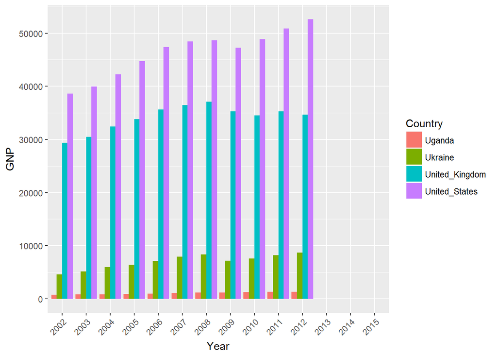

```r
final_df %>%
    mutate(GNP=as.numeric(`Gross national income per capita (PPP int. $)`)) %>%
    dplyr::group_by(Country) %>%
    ggplot(., aes(x=Year ,y=GNP))+
    geom_bar(aes(fill = Country), position = "dodge", stat = "identity")+
    theme(axis.text.x=element_text(angle=45,hjust=1))
```

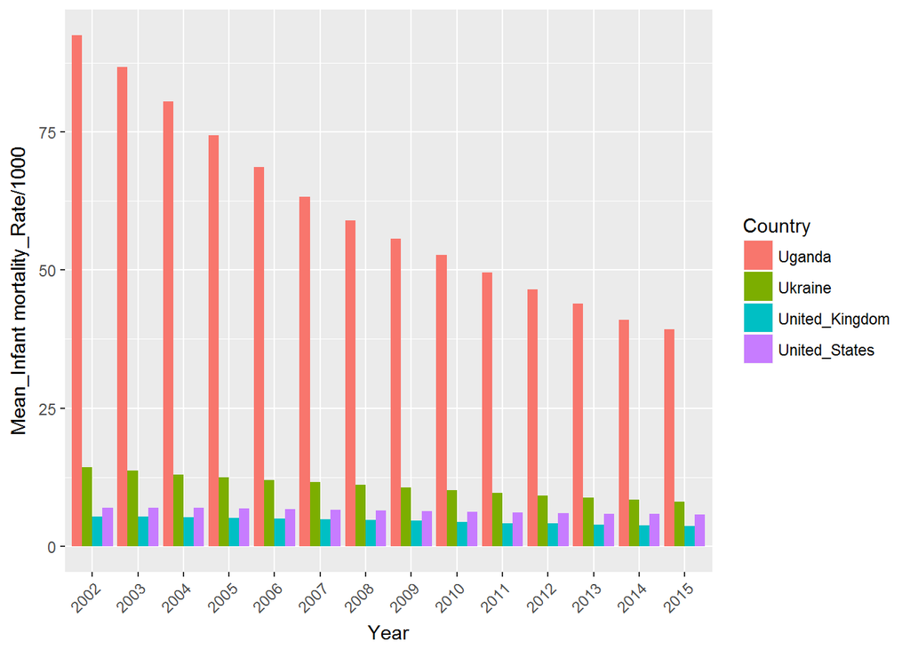

```r
final_df %>%
    dplyr::group_by(Country) %>%
    ggplot(., aes(x=Year ,y=`Mean_Infant mortality_Rate/1000`))+
    geom_bar(aes(fill = Country), position = "dodge", stat = "identity")+
    theme(axis.text.x=element_text(angle=45,hjust=1))
```

```r
final_df_display <- final_df %>%
    arrange(Country,Year) %>%
    select(.,Country,`Mean_Infant mortality_Rate/1000`)
```

- Uganda seems to have reduced it’s infant mortality rate by over 50%

## Numerical display of Infant Mortality

```r
## Numerical display
kable(final_df_display)
```

| Country | Mean_Infant mortality_Rate/1000 |
| --- | --- |
| Uganda | 92.5 |
| Uganda | 86.7 |
| Uganda | 80.5 |
| Uganda | 74.4 |
| Uganda | 68.6 |
| Uganda | 63.3 |
| Uganda | 58.9 |
| Uganda | 55.7 |
| Uganda | 52.7 |
| Uganda | 49.5 |
| Uganda | 46.5 |
| Uganda | 43.9 |
| Uganda | 41.0 |
| Uganda | 39.2 |
| Ukraine | 14.3 |
| Ukraine | 13.7 |
| Ukraine | 13.0 |
| Ukraine | 12.5 |
| Ukraine | 12.0 |
| Ukraine | 11.6 |
| Ukraine | 11.1 |
| Ukraine | 10.6 |
| Ukraine | 10.1 |
| Ukraine | 9.6 |
| Ukraine | 9.2 |
| Ukraine | 8.8 |
| Ukraine | 8.4 |
| Ukraine | 8.1 |
| United_Kingdom | 5.4 |
| United_Kingdom | 5.4 |
| United_Kingdom | 5.3 |
| United_Kingdom | 5.1 |
| United_Kingdom | 5.0 |
| United_Kingdom | 4.9 |
| United_Kingdom | 4.8 |
| United_Kingdom | 4.6 |
| United_Kingdom | 4.4 |
| United_Kingdom | 4.2 |
| United_Kingdom | 4.1 |
| United_Kingdom | 3.9 |
| United_Kingdom | 3.8 |
| United_Kingdom | 3.7 |
| United_States | 6.9 |
| United_States | 6.9 |
| United_States | 6.9 |
| United_States | 6.8 |
| United_States | 6.7 |
| United_States | 6.6 |
| United_States | 6.5 |
| United_States | 6.4 |
| United_States | 6.2 |
| United_States | 6.1 |
| United_States | 6.0 |
| United_States | 5.9 |
| United_States | 5.8 |
| United_States | 5.7 |

## Display of infant Mortality with the 3 samples closer in scale

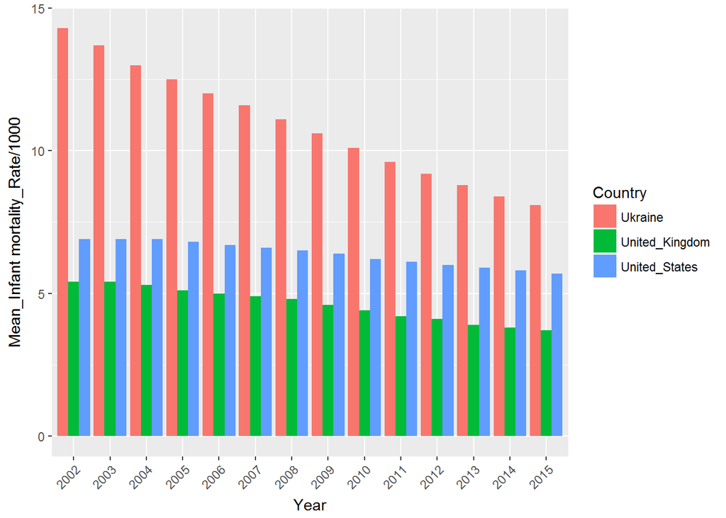

```r
final_df %>%
    dplyr::filter(., Country %in% c("United_Kingdom", "Ukraine","United_States")) %>%
    dplyr::group_by(Country) %>%
    ggplot(., aes(x=Year ,y=`Mean_Infant mortality_Rate/1000`))+
    geom_bar(aes(fill = Country), position = "dodge", stat = "identity")+
    theme(axis.text.x=element_text(angle=45,hjust=1))
```

```r
final_df
```

```
## # A tibble: 56 x 19
##    Coun~ Year  `Gro~ `Hos~ `Mea~ Min_~ Max_~ `Mea~ `Min~ Max_~ `Num~ `Num~
##    <chr> <chr> <dbl> <dbl> <dbl> <dbl> <dbl> <dbl> <dbl> <dbl> <dbl> <dbl>
##  1 Ugan~ 2015     NA NA      202   120   304  39.2  35.4  43.3  38.0  93.0
##  2 Ugan~ 2014     NA NA      202   127   294  41.0  37.8  44.5  38.0  97.0
##  3 Ugan~ 2005    890 NA      233   156   325  74.4  70.3  78.7  38.0 155
##  4 Ugan~ 2004    840 NA      240   169   323  80.5  76.3  85.0  39.0 164
##  5 Ugan~ 2003    800 NA      248   172   336  86.7  82.0  91.4  39.0 173
##  6 Ugan~ 2002    760 NA      256   171   358  92.5  87.5  97.5  40.0 181
##  7 Ugan~ 2013     NA NA      203   134   288  43.9  40.8  47.2  38.0 103
##  8 Ugan~ 2012   1320 NA      205   135   289  46.5  43.2  50.0  38.0 109
##  9 Ugan~ 2011   1310 NA      207   143   283  49.5  46.1  53.3  38.0 114
## 10 Ugan~ 2010   1240  5.00   210   139   296  52.7  49.2  56.4  38.0 119
## # ... with 46 more rows, and 7 more variables: `Poliomyelitis - number of
## #   reported cases` <dbl>, Mean_Tuberculosis_Coverage <dbl>,
## #   Min_Tuberculosis_Coverage <dbl>, Max_Tuberculosis_Coverage <dbl>,
## #   `Mean_Under-five_Mortality_Rate/1000` <dbl>,
## #   `Min_Under-five_Mortality_Rate` <dbl>, `Max_Under-five_Mortality_Rate`
## #   <dbl>
```

- Ukraine has seen a reduction of around 40%
- US and UK have also seen a reduction, however UK seems to have a more substantial reduction(30%) over the US reduction of (17%)

## Look at Tuberculosis

```r
final_df
```

```
## # A tibble: 56 x 19
##    Coun~ Year  `Gro~ `Hos~ `Mea~ Min_~ Max_~ `Mea~ `Min~ Max_~ `Num~ `Num~
##    <chr> <chr> <dbl> <dbl> <dbl> <dbl> <dbl> <dbl> <dbl> <dbl> <dbl> <dbl>
##  1 Ugan~ 2015     NA NA      202   120   304  39.2  35.4  43.3  38.0  93.0
##  2 Ugan~ 2014     NA NA      202   127   294  41.0  37.8  44.5  38.0  97.0
##  3 Ugan~ 2005    890 NA      233   156   325  74.4  70.3  78.7  38.0 155
##  4 Ugan~ 2004    840 NA      240   169   323  80.5  76.3  85.0  39.0 164
##  5 Ugan~ 2003    800 NA      248   172   336  86.7  82.0  91.4  39.0 173
##  6 Ugan~ 2002    760 NA      256   171   358  92.5  87.5  97.5  40.0 181
##  7 Ugan~ 2013     NA NA      203   134   288  43.9  40.8  47.2  38.0 103
##  8 Ugan~ 2012   1320 NA      205   135   289  46.5  43.2  50.0  38.0 109
##  9 Ugan~ 2011   1310 NA      207   143   283  49.5  46.1  53.3  38.0 114
## 10 Ugan~ 2010   1240  5.00   210   139   296  52.7  49.2  56.4  38.0 119
## # ... with 46 more rows, and 7 more variables: `Poliomyelitis - number of
## #   reported cases` <dbl>, Mean_Tuberculosis_Coverage <dbl>,
## #   Min_Tuberculosis_Coverage <dbl>, Max_Tuberculosis_Coverage <dbl>,
## #   `Mean_Under-five_Mortality_Rate/1000` <dbl>,
## #   `Min_Under-five_Mortality_Rate` <dbl>, `Max_Under-five_Mortality_Rate`
## #   <dbl>
```

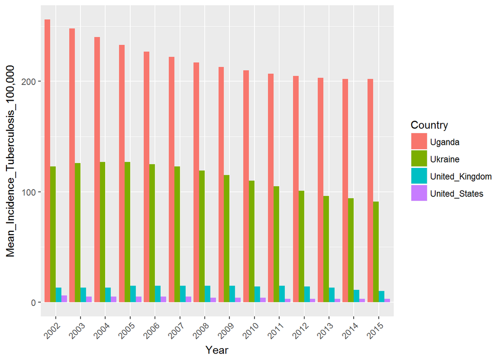

```r
final_df %>%
    dplyr::filter(., Country %in% c("Uganda", "Ukraine","United_Kingdom","United_States")) %>%
    dplyr::group_by(Country) %>%
    ggplot(., aes(x=Year ,y=`Mean_Incidence_Tuberculosis_100,000`))+
    geom_bar(aes(fill = Country), position = "dodge", stat = "identity")+
    theme(axis.text.x=element_text(angle=45,hjust=1))
```

- Uganda seems to have seen some moderate improvement over the past 13 years in tuberculosis, but the rate is relatively high still
- Ukraine seems to have has a similar improvement

## Look at Tuberculosis in Heavily industrialized nations( UK, US)

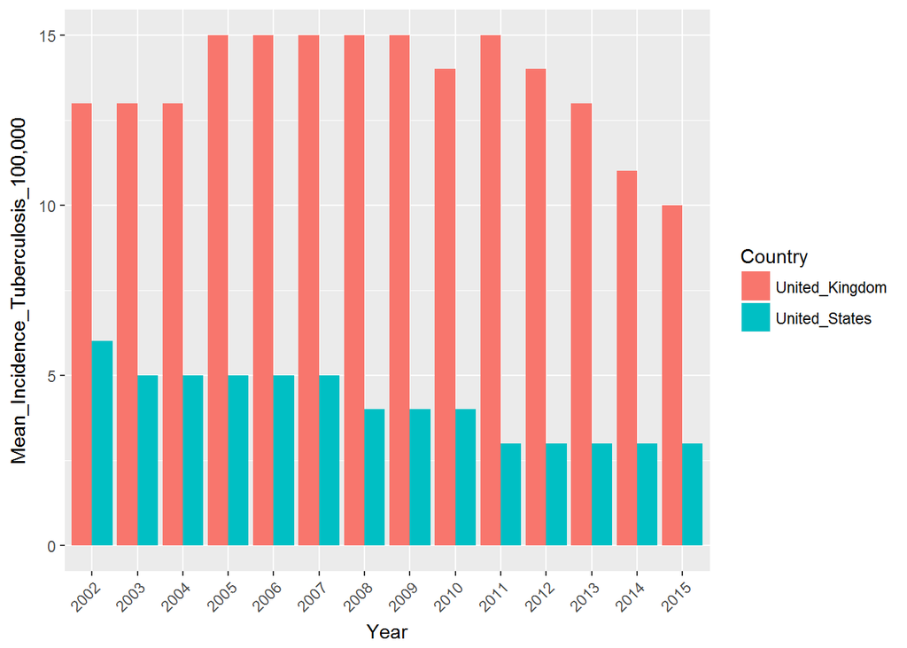

```r
final_df %>%
    dplyr::filter(., Country %in% c("United_Kingdom","United_States")) %>%
    dplyr::group_by(Country) %>%
    ggplot(., aes(x=Year ,y=`Mean_Incidence_Tuberculosis_100,000`))+
    geom_bar(aes(fill = Country), position = "dodge", stat = "identity")+
    theme(axis.text.x=element_text(angle=45,hjust=1))
```

- England appears to have made some moderate improvement in the past several years
- Tuberculosis in the United states is almost non-existant and it appears it is decreasing